# Homework 3 Answers

BSTA 512/612

Due: Friday February 14, 2025 at 11pm

Author

Your name here!!!

Modified

February 19, 2025

Answers are not necessarily complete! This is just meant to serve as a check if you are stuck.

## Questions

### Question 1

This question and data are adapted from [this textbook](https://catalog.lib.uchicago.edu/vufind/Record/7546272).

In an experiment designed to describe the dose–response curve for vitamin K, individual rats were depleted of their vitamin K reserves and then fed dried liver for 4 days at different dosage levels. The response of each rat was measured as the concentration of a clotting agent needed to clot a sample of its blood in 3 minutes. The results of the experiment on 12 rats are given in the following table; values are expressed in common logarithms for both dose and response.

```r
clot = read_excel(here("data/CH05Q09.xls"))
clot %>% gt() %>%
  cols_label(RAT = md("**Rat**"),
             LOGCONC = md("**Log10 Concentration (Y)**"),
             LOGDOSE = md("**Log10 Dose (X)**"))
```

| **Rat** | **Log10 Concentration (Y)** | **Log10 Dose (X)** |
| --- | --- | --- |
| 1 | 2.65 | 0.18 |
| 2 | 2.25 | 0.33 |
| 3 | 2.26 | 0.42 |
| 4 | 1.95 | 0.54 |
| 5 | 1.72 | 0.65 |
| 6 | 1.60 | 0.75 |
| 7 | 1.55 | 0.83 |
| 8 | 1.32 | 0.92 |
| 9 | 1.13 | 1.01 |
| 10 | 1.07 | 1.04 |
| 11 | 0.95 | 1.09 |
| 12 | 0.88 | 1.15 |

Use the log-transformed values as given in the dataset.

Use the following scatterplot to build your answers off of:

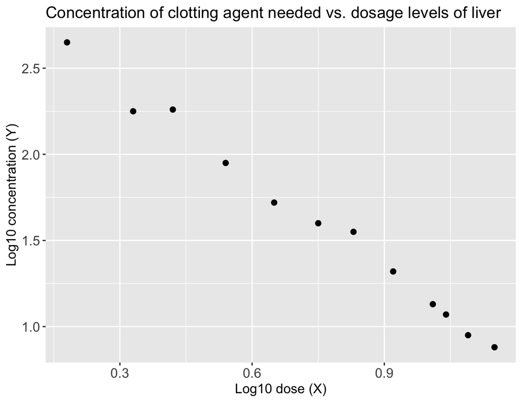

#### Part a

```r
summary(clot_mod)
```

```
Call:
lm(formula = LOGCONC ~ LOGDOSE, data = clot)

Residuals:
      Min        1Q    Median        3Q       Max
-0.097151 -0.026859 -0.003392  0.028279  0.095355

Coefficients:
            Estimate Std. Error t value Pr(>|t|)
(Intercept)  2.93620    0.04230   69.41 9.39e-15 ***
LOGDOSE     -1.78501    0.05267  -33.89 1.18e-11 ***
---
Signif. codes:  0 '***' 0.001 '**' 0.01 '*' 0.05 '.' 0.1 ' ' 1

Residual standard error: 0.05589 on 10 degrees of freedom
Multiple R-squared:  0.9914,    Adjusted R-squared:  0.9905
F-statistic:  1149 on 1 and 10 DF,  p-value: 1.182e-11
```

#### Part b

| term | df | sumsq | meansq | statistic | p.value |
| --- | --- | --- | --- | --- | --- |
| LOGDOSE | 1 | 3.58845400 | 3.588454000 | 1148.759 | 1.182233e-11 |
| Residuals | 10 | 0.03123767 | 0.003123767 | NA | NA |

#### Part c

$$F = 1148.759$$

#### Part d

Not shown bc answer is complete solution

### Question 2

#### Part a

```
[1] -0.9956757
```

#### Part b

| term | df | sumsq | meansq | statistic | p.value |
| --- | --- | --- | --- | --- | --- |
| LOGDOSE | 1 | 3.58845400 | 3.588454000 | 1148.759 | 1.182233e-11 |
| Residuals | 10 | 0.03123767 | 0.003123767 | NA | NA |

```
[1] 0.9913701
```

#### Part c

Not given

### Question 3

```r
if(!require(Sleuth3)) { install.packages("Sleuth3"); library(Sleuth3) }
q1_data = ex0824
```

#### Part a

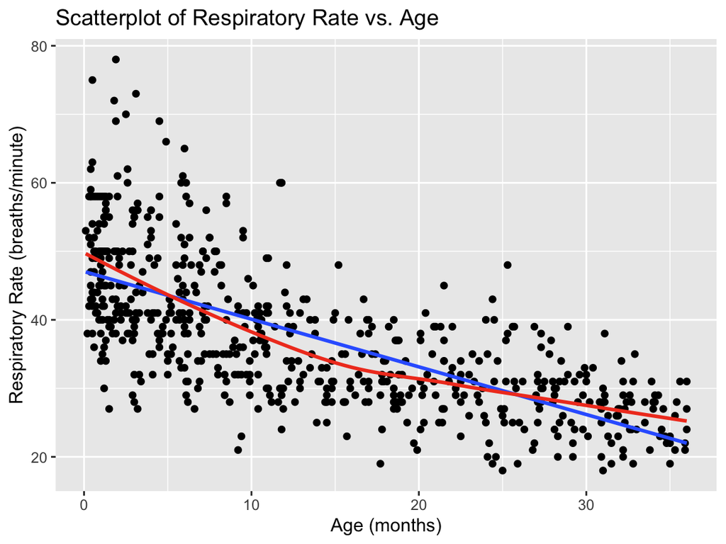

#### Part b

Not given

#### Part c

Fit the regression model, display the regression table, and write out the fitted regression line.

| term | estimate | std.error | statistic | p.value |
| --- | --- | --- | --- | --- |
| (Intercept) | 47.0521633 | 0.50421678 | 93.31733 | 0.000000e+00 |
| Age | -0.6957134 | 0.02937509 | -23.68378 | 1.168799e-88 |

$$\begin{aligned}
\widehat{\text{RR}} &= 47.05 -0.7 \cdot \text{Age}
\end{aligned}$$

#### Part d

```
[1] "Rate"       "Age"        ".fitted"    ".resid"     ".hat"
[6] ".sigma"     ".cooksd"    ".std.resid"
```

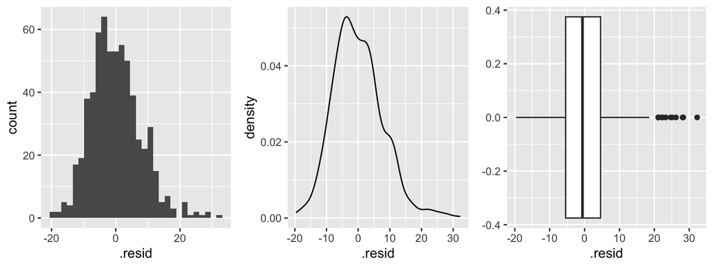

#### Part e

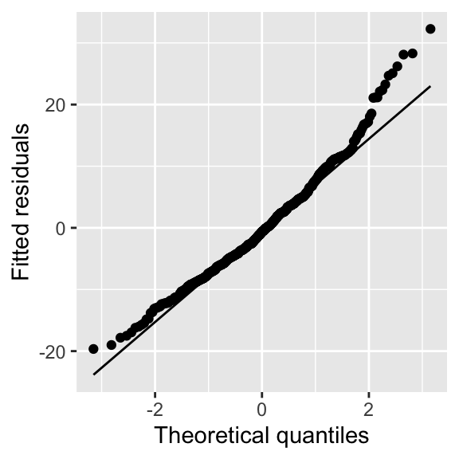

#### Part f

| statistic | p.value | method |
| --- | --- | --- |
| 0.9782974 | 6.177141e-08 | Shapiro-Wilk normality test |

#### Part g

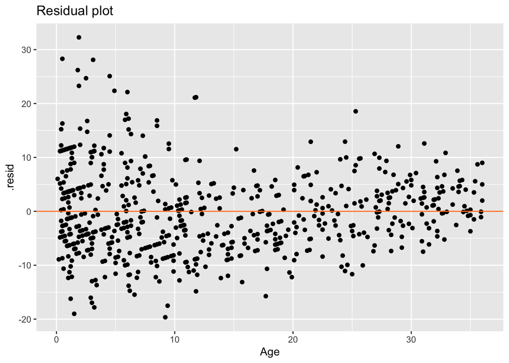

#### Part h

```
# A tibble: 0 × 8
# ℹ 8 variables: Rate <int>, Age <dbl>, .fitted <dbl>, .resid <dbl>,
#   .hat <dbl>, .sigma <dbl>, .cooksd <dbl>, .std.resid <dbl>
```

#### Part i

```
# A tibble: 618 × 8
    Rate   Age .fitted .resid    .hat .sigma .cooksd .std.resid
   <int> <dbl>   <dbl>  <dbl>   <dbl>  <dbl>   <dbl>      <dbl>
 1    78   1.9    45.7   32.3 0.00347   7.74  0.0296       4.12
 2    75   0.5    46.7   28.3 0.00395   7.76  0.0259       3.62
 3    73   3.1    44.9   28.1 0.00310   7.77  0.0201       3.59
 4    72   1.8    45.8   26.2 0.00350   7.78  0.0197       3.35
 5    70   2.5    45.3   24.7 0.00328   7.78  0.0164       3.15
 6    69   1.9    45.7   23.3 0.00347   7.79  0.0154       2.97
 7    69   4.5    43.9   25.1 0.00273   7.78  0.0140       3.20
 8    66   4.9    43.6   22.4 0.00263   7.80  0.0107       2.85
 9    27   1.5    46.0  -19.0 0.00360   7.81  0.0107      -2.43
10    48  25.3    29.5   18.5 0.00361   7.81  0.0102       2.37
# ℹ 608 more rows
```

#### Part j

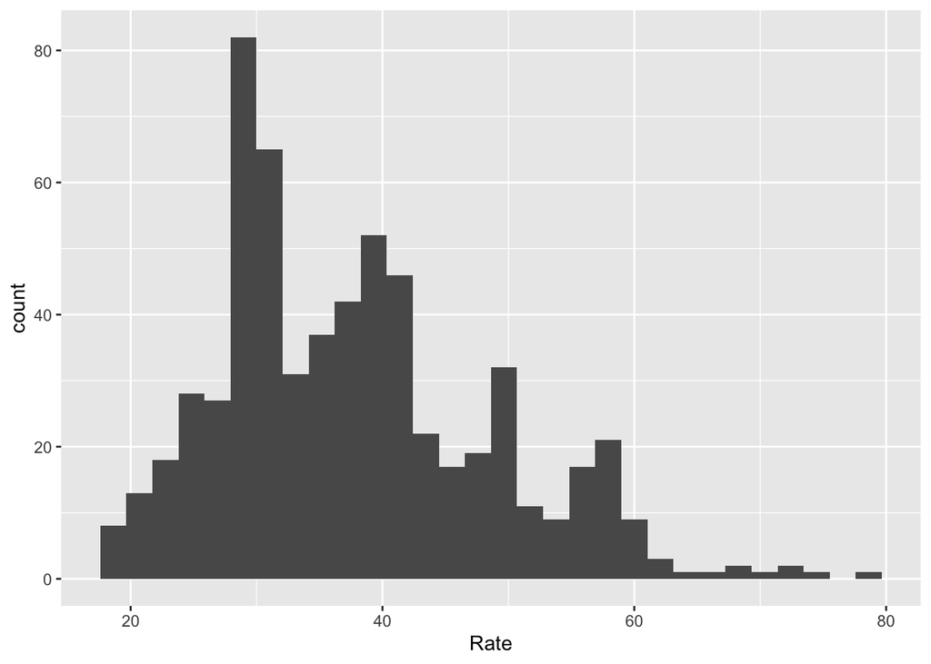

#### Part k

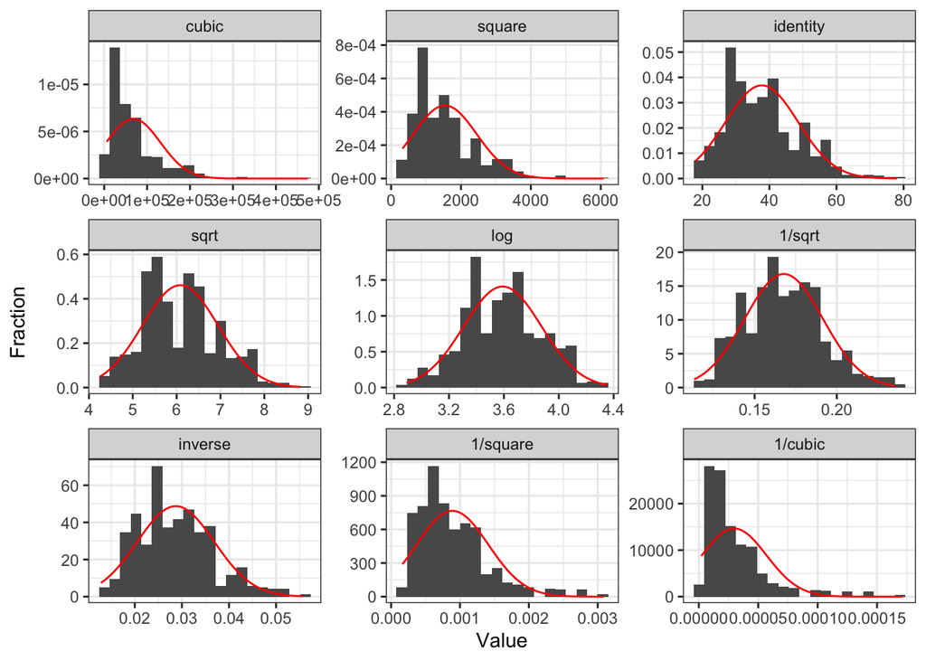

#### Part l

Not given

#### Part m

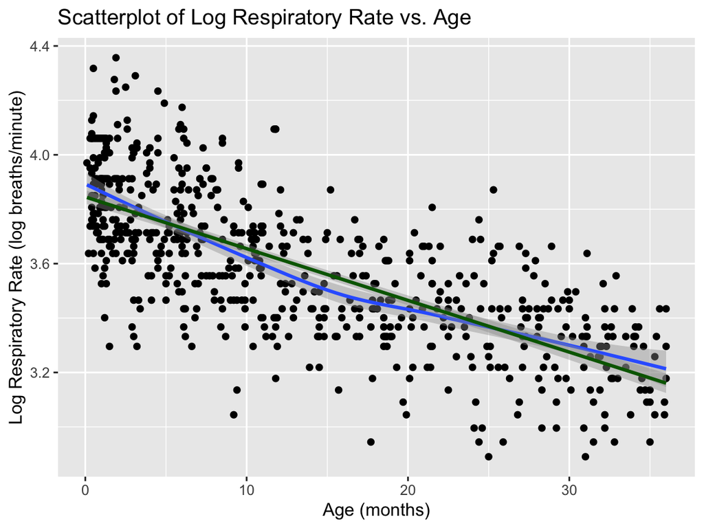

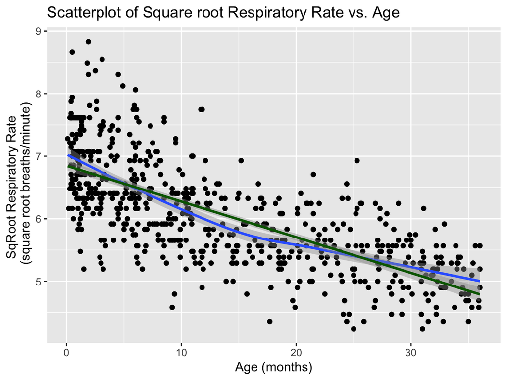

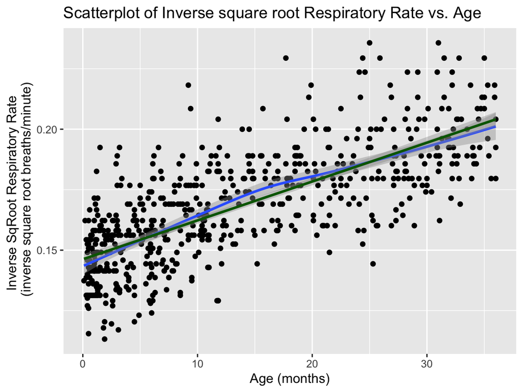

#### Part n

**For the log-transformed Rate:**

```r
q1_model2 = lm (Rate_log ~ Age, data = q1_data2)
q1_mod_t2 = tidy(q1_model2)
q1_mod_t2 %>% gt()
```

| term | estimate | std.error | statistic | p.value |
| --- | --- | --- | --- | --- |
| (Intercept) | 3.84511854 | 0.0126276539 | 304.49984 | 0.000000e+00 |
| Age | -0.01900896 | 0.0007356727 | -25.83888 | 2.740318e-100 |

#### Part o

**For log-transformed Rate:**

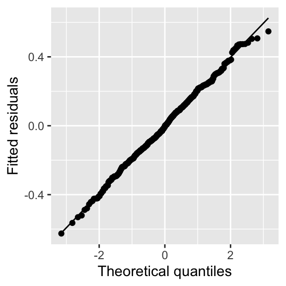

#### Part p

**For log-transformed Rate:**

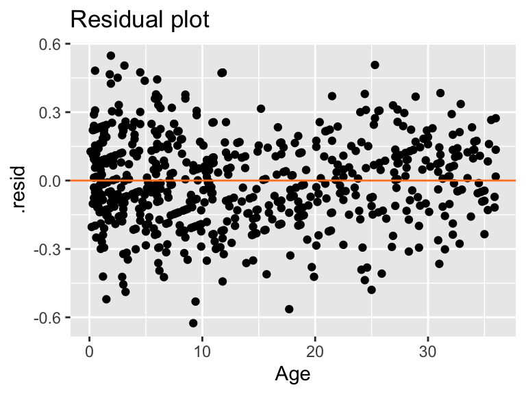

#### Part q

Not given

### Question 4

```r
dep_df = read_sas(here("data/completedata.sas7bdat"))
```

#### Part a

| term | estimate | std.error | statistic | p.value | conf.low | conf.high |
| --- | --- | --- | --- | --- | --- | --- |
| (Intercept) | 6.4144 | 2.0501 | 3.1288 | 0.0018 | 2.3882 | 10.4406 |
| Fatalism | 0.1527 | 0.0452 | 3.3784 | 0.0008 | 0.0639 | 0.2414 |
| Optimism | −0.3179 | 0.0722 | −4.4058 | 0.0000 | −0.4596 | −0.1762 |
| Spirituality | 0.3587 | 0.1291 | 2.7781 | 0.0056 | 0.1051 | 0.6122 |

Another fun way to display:

```r
tbl_regression(q2_mod_f1, intercept = T)
```

| **Characteristic** | **Beta** | **95% CI**<sup>1</sup> | **p-value** |
| --- | --- | --- | --- |
| (Intercept) | 6.4 | 2.4, 10 | 0.002 |
| Fatalism | 0.15 | 0.06, 0.24 | <0.001 |
| Optimism | -0.32 | -0.46, -0.18 | <0.001 |
| Spirituality | 0.36 | 0.11, 0.61 | 0.006 |

<sup>1</sup> CI = Confidence Interval

#### Part c

Not given

#### Part d

$$\begin{aligned}
\widehat{\text{Depression}} &= 5.39 + 0.15 \cdot \text{Fatalism}
\end{aligned}$$